# R Notebook

# Abstract

# Introduction

## Background

## Problem description

## Earlier work ?

# Model

## Data set

## Background subtraction

## Priors

TODO: - Random frames, så man kan göra bakgrund, priors på position och size och folk - Hoppa mellan k - Ellipser - Bättre priors på pos, size conditional på xy - Optimera likelihood

Idé: eigen value compression för att få fram bakgrund

MVP: - Bakgrundsmodel 1. Average över frames på samma klipp, differencing / threshold 2. Average över frames flera klipp 3. Gaussian, över sigma 4. Frame differencing - Priors 1. Uniform 2. Parametrisk x, y, k, size från heat map 2.5 Residual (det som inte täcks av de andra) 3. Conditional på förra framen - Likelihood 1. Rektangel överlapp 1.1 Rektangel, hårt straff 1.2 Rektagel, mjukt straff 2. Ellips överlapp 3. Parametriska människoformer - Proposal 1. Uniform 2. K-means på pixlar / ellipsfitting - Accuracy 1. Antal personer 2. Antal personer + överlapp 3. Antal personer + labels - Över frames 1. Inget 2. Drift / diffusion

```r
library(jpeg)
jj <- readJPEG("./mall_dataset/frames/seq_000001.jpg",native=FALSE)
plot(0:1,0:1,type="n",ann=FALSE,axes=FALSE)

w <- 640
h <- 480

jj[seq(100, 1000)] = rep(1, 901)
jj[seq(100, 1000) + w*h] = rep(0, 901)
jj[seq(100, 1000) + 2*w*h] = rep(0, 901)


rasterImage(jj,0,0,1,1)
```

```r
library(rmatio)
ground_truth <- read.mat("./mall_dataset/mall_gt.mat")


# ground_truth$frame[[1]][[2000]]$loc[[1]][,1]

jj <- readJPEG("./mall_dataset/frames/seq_000001.jpg",native=FALSE)
plot(0:1,0:1,type="n",ann=FALSE,axes=FALSE)

rasterImage(jj,0,0,1,1)

points(ground_truth$frame[[1]][[1]]$loc[[1]][,1] / w, 1-ground_truth$frame[[1]][[1]]$loc[[1]][,2] / h)
```

```r
jpgs <- list()
# frames <- 2000
frames <- 1000
# background <- rep(0, w*h*3)
background <- jj / frames
for (f in 2:frames) {
  jpg <- readJPEG(paste("./mall_dataset/frames/seq_",strrep("0", 6-log10(f + 1)),f,".jpg", sep=""),native=FALSE)
  # for (i in 1:(w*h*3)) {
  for (i in 1:h) {
    for (j in 1:w) {
      for (c in 1:3) {
        background[i, j, c] <- background[i, j, c] + jpg[i, j, c] / frames
      }
    }
  }
}

for (i in 1:h) {
  for (j in 1:w) {
    for (c in 1:3) {
        background[i, j, c] <- max(min(background[i, j, c], 1), 0)
    }
  }
}
plot(0:1,0:1,type="n",ann=FALSE,axes=FALSE)
# rasterImage(background,0,0,1,1)
rasterImage(background,0,0,1,1)
```

```r
# jj <- readJPEG("./mall_dataset/frames/seq_000001.jpg",native=FALSE)
plot(0:1,0:1,type="n",ann=FALSE,axes=FALSE)

rasterImage(jj,0,0,1,1)

locs <- list()

for (f in 1:frames) {
  points(ground_truth$frame[[1]][[f]]$loc[[1]][,1] / w, 1-ground_truth$frame[[1]][[f]]$loc[[1]][,2] / h)
}
```

```r
jj <- readJPEG("./mall_dataset/frames/seq_000001.jpg",native=FALSE)
plot(0:1,0:1,type="n",ann=FALSE,axes=FALSE)

interp <- function(x) -20*x^7+70*x^6-84*x^5+35*x^4

for (i in 1:h) {
  for (j in 1:w) {
    # for (c in 1:3) {
        # jj[i, j, c] <- max(min(jj[i, j, c] - background[i, j, c], 1), 0)
        # jj[i, j, c] <- max(min(-(sum(jj[i, j, c(1,2,3)])/3 - sum(background[i, j, c(1,2,3)])/3), 1), 0)
        # jj[i, j, c] <- max(min(mean(jj[i, j, c(1,2,3)]), 1), 0)
        # jj[i, j, c(1,2,3)] <- max(min(interp(1-(mean(jj[i, j, c(1,2,3)])-mean(background[i, j, c(1,2,3)]))), 1), 0)
        jj[i, j, c(1,2,3)] <- max(min(
          # ifelse(abs(mean(jj[i, j, c(1,2,3)])-mean(background[i, j, c(1,2,3)])) < 0.1, 0, mean(jj[i, j, c(1,2,3)]))
          ifelse(abs(mean(jj[i, j, c(1,2,3)])-mean(background[i, j, c(1,2,3)])) < 0.1, 0, 1)
        , 1), 0)
    # }
  }
}

rasterImage(jj,0,0,1,1)
# points(ground_truth$frame[[1]][[1]]$loc[[1]][,1] / w, 1-ground_truth$frame[[1]][[1]]$loc[[1]][,2] / h, col="red")
```

```r
jj <- readJPEG("./mall_dataset/frames/seq_000001.jpg",native=FALSE)
plot(0:1,0:1,type="n",ann=FALSE,axes=FALSE)
rasterImage(jj,0,0,1,1)

plot(0:1,0:1,type="n",ann=FALSE,axes=FALSE)
rasterImage(background,0,0,1,1)
```

```r
r <- c()
g <- c()
# frames <- 2000
frames <- 1000
i <- 200
j <- 300
# background <- rep(0, w*h*3)
for (f in 1:frames) {
  jpg <- readJPEG(paste("./mall_dataset/frames/seq_",strrep("0", 6-log10(f + 1)),f,".jpg", sep=""),native=FALSE)
  # for (i in 1:(w*h*3)) {
  # for (i in 1:h) {
    # for (j in 1:w) {

      r <- c(r, jpg[i, j, 1])
      g <- c(g, jpg[i, j, 2])
    # }
  # }
}

plot(r, g, xlim=c(0,1), ylim=c(0,1))
```

```r
frames <- seq(1, 2000, by=2000/200)
frame_paths <- paste0("./mall_dataset/frames/seq_",strrep("0", 6-log10(frames + 1)),frames,".jpg")
# frames <- paste0("./mall_dataset/frames/seq_",strrep("0", 6-log10(1:100 + 1)),1:100,".jpg")
library(magick)
m <- image_read(frame_paths)
m <- image_animate(m)
image_write(m, "./movie10.gif")
```

```r
library(jpeg)
jj <- readJPEG("./caviar_frames/ThreePastShop1cor0000.jpg",native=FALSE)
plot(0:1,0:1,type="n",ann=FALSE,axes=FALSE)

w <- 384
h <- 288

# jj[seq(100, 1000)] = rep(1, 901)
# jj[seq(100, 1000) + w*h] = rep(0, 901)
# jj[seq(100, 1000) + 2*w*h] = rep(0, 901)


rasterImage(jj,0,0,1,1)
```

```r
library(XML)
# library(methods)

# f <- 500
# f <- 1200
for (f in round(seq(2, 1600, length.out = 100))) {
# jj <- readJPEG(paste("./caviar_frames/ThreePastShop1cor",strrep("0", 4-log10(f-1 + 1)),f-1,".jpg", sep=""), native=FALSE)
jj <- readJPEG(paste("./caviar_frames2/TwoEnterShop2cor",strrep("0", 4-log10(f-1 + 1)),f-1,".jpg", sep=""), native=FALSE)

# result <- xmlParse(file = "./c3ps1gt.xml")
result <- xmlParse(file = "./c2es2gt.xml")

# print(result)

plot(0:1,0:1,type="n",ann=FALSE,axes=FALSE)
rasterImage(jj,0,0,1,1)

rootnode <- xmlRoot(result)
is<-1:length(xmlElementsByTagName(rootnode[[f]][[1]], "object"))
for (i in is) {
  attrs <- xmlAttrs(rootnode[[f]][[1]][[i]][[2]])
  box <- list(
    w=as.numeric(attrs["w"]),
    h=as.numeric(attrs["h"]),
    x=as.numeric(attrs["xc"]),
    y=as.numeric(attrs["yc"]),
    xy = c(as.numeric(attrs["xc"]), as.numeric(attrs["yc"]))
  )
  box

  rect((box$x - box$w/2) / w, 1-(box$y - box$h/2) / h, (box$x + box$w/2)/w, 1-(box$y + box$h/2)/h)
}

}
```

```r
# rect((box$x-box$w/4) / w, 1-(box$y - box$h/2) / h, (box$x-box$w/4)/w, 1-(box$y + box$h/2)/h)
# points(box$x/w, 1-box$y/h, col="green")
# points((box$x-box$w)/w, 1-box$y/h, col="red")
# points((box$x-box$w/2)/w, 1-box$y/h, col="red")
# points((box$x+box$w)/w, 1-box$y/h, col="red")
# points((box$x+box$w/2)/w, 1-box$y/h, col="red")
#
# points((box$x)/w, 1-(box$y-box$h/2)/h, col="red")
# points((box$x)/w, 1-(box$y-box$h)/h, col="red")
# points((box$x)/w, 1-(box$y+box$h/2)/h, col="red")
# points((box$x)/w, 1-(box$y+box$h)/h, col="red")
#
# p1 <- c(91-10,163)
# # p2 <- c(91/w,163/h)
# p3 <- c(98-10,266)
# p4 <- c(322-10,265)
#
# points(p1[1]/w, 1-p1[2]/h, col="orange")
# points(p3[1]/w, 1-p3[2]/h, col="orange")
# points(p4[1]/w, 1-p4[2]/h, col="orange")

# Y <- (p1-p3)
# # Y <- (p3-p1)
# Y <- Y/norm(Y, type="2")
# X <- p4-p3
# X <- X/norm(X, type="2")
#
# # points(box$xy%*%X/w, 1-box$xy%*%Y/h, col="green")
# p <- box$x%*%X + box$y%*%Y
# points(p[1]/w, 1-p[2]/h, col="blue")

# lines(rep(0.5, 100), seq(0.01, 1, 0.01))

# pp <- c(seq(from=0*Y[1], to=1*Y[1], length.out = 100), seq(from=0*Y[2], to=1*Y[2], length.out = 100))
# # pp <- rep(0.5*X, 100) + c(seq(from=0*Y[1], to=1*Y[1], length.out = 100), seq(from=0*Y[2], to=1*Y[2], length.out = 100))
# lines(pp[seq(1, 200, by=2)], 1-pp[seq(2, 200, by=2)])
# %*%

# plot(0:1,0:1,type="n",ann=FALSE,axes=FALSE)
# for (t in seq(0, 1, by=0.01)) {
# t <- seq(0, h/2, by=0.01)
# s <- seq(0, w/2, by=0.01)
#
# for (t in seq(0, h/2, length.out = 20)) {
#   for (s in seq(0, w/2, length.out = 20)) {
#     p <- Y*t + X*s
#     # p <- Y*t
#     # points(p[1]/w + p3[1]/w, 1-(p[2] + p3[2])/h)
#     points(p[1]/w, -(p[2])/h)
#     # points(p[1]/w + p3[1]/w, 1-(Y[2]*t/h + p3[2])/h)
#     # points(Y[1]*t/w+ p3[1]/w, 1-(Y[2]*t+ p3[2])/h)
#   }
# }
# p <- X*box$x + Y*box$y
# # # p <- Y*t
# points(p[1]/w, -(p[2])/h, col="purple")
# points(0/w, h/h, col="purple")


# points(Y[1]*t/w+ p3[1]/w, 1-(Y[2]*t+ p3[2])/h)
# points(Y[1]*t/w+ p3[1]/w, 1-(Y[2]*t+ p3[2])/h)
# points(Y[1]*box$y/w+ p3[1]/w, 1-(Y[2]*box$y+ p3[2])/h)


# points(((p1-p3)[1]*t)/w, 1-((p1-p3)[2]*t)/h, col="green")
# }
```

```r
# frames <- 2000
frames <- round(seq(2, 1600, length.out = 100))
# background <- rep(0, w*h*3)
jj <- readJPEG("./caviar_frames/ThreePastShop1cor0000.jpg",native=FALSE)
background <- jj / length(frames)
for (f in frames) {
# jj <- readJPEG(paste("./caviar_frames/ThreePastShop1cor",strrep("0", 4-log10(f-1 + 1)),f-1,".jpg", sep=""), native=FALSE)
  jpg <- readJPEG(paste("./caviar_frames2/TwoEnterShop2cor",strrep("0", 4-log10(f-1 + 1)),f-1,".jpg", sep=""), native=FALSE)
  # for (i in 1:(w*h*3)) {
  for (i in 1:h) {
    for (j in 1:w) {
      for (c in 1:3) {
        background[i, j, c] <- background[i, j, c] + jpg[i, j, c] / length(frames)
      }
    }
  }
}

for (i in 1:h) {
  for (j in 1:w) {
    for (c in 1:3) {
        background[i, j, c] <- max(min(background[i, j, c], 1), 0)
    }
  }
}
plot(0:1,0:1,type="n",ann=FALSE,axes=FALSE)
# rasterImage(background,0,0,1,1)
rasterImage(background,0,0,1,1)

writeJPEG(background, "bg.jpg")
```

```r
for (f in round(seq(2, 1600, length.out = 10))) {
# jj <- readJPEG(paste("./caviar_frames/ThreePastShop1cor",strrep("0", 4-log10(f-1 + 1)),f-1,".jpg", sep=""), native=FALSE)
jj <- readJPEG(paste("./caviar_frames2/TwoEnterShop2cor",strrep("0", 4-log10(f-1 + 1)),f-1,".jpg", sep=""), native=FALSE)
plot(0:1,0:1,type="n",ann=FALSE,axes=FALSE)
rasterImage(jj,0,0,1,1)

interp <- function(x) -20*x^7+70*x^6-84*x^5+35*x^4

for (i in 1:h) {
  for (j in 1:w) {
    # for (c in 1:3) {
        # jj[i, j, c] <- max(min(jj[i, j, c] - background[i, j, c], 1), 0)
        # jj[i, j, c] <- max(min(-(sum(jj[i, j, c(1,2,3)])/3 - sum(background[i, j, c(1,2,3)])/3), 1), 0)
        # jj[i, j, c] <- max(min(mean(jj[i, j, c(1,2,3)]), 1), 0)
        # jj[i, j, c(1,2,3)] <- max(min(interp(1-(mean(jj[i, j, c(1,2,3)])-mean(background[i, j, c(1,2,3)]))), 1), 0)
        jj[i, j, c(1,2,3)] <- max(min(
          # ifelse(abs(mean(jj[i, j, c(1,2,3)])-mean(background[i, j, c(1,2,3)])) < 0.1, 0, mean(jj[i, j, c(1,2,3)]))
          ifelse(abs(mean(jj[i, j, c(1,2,3)])-mean(background[i, j, c(1,2,3)])) < 0.2, 0, 1)
        , 1), 0)
    # }
  }
}

plot(0:1,0:1,type="n",ann=FALSE,axes=FALSE)
rasterImage(jj,0,0,1,1)
# points(ground_truth$frame[[1]][[1]]$loc[[1]][,1] / w, 1-ground_truth$frame[[1]][[1]]$loc[[1]][,2] / h, col="red")
}
# plot(0:1,0:1,type="n",ann=FALSE,axes=FALSE)
# rasterImage(background,0,0,1,1)
```

```r
# library(methods)

# f <- 500
# f <- 1200
plot(0:1,0:1,type="n",ann=FALSE,axes=FALSE)
rasterImage(background,0,0,1,1)

result <- xmlParse(file = "./c2es2gt.xml")
rootnode <- xmlRoot(result)

for (f in round(seq(2, 1600, 1))) {
# jj <- readJPEG(paste("./caviar_frames/ThreePastShop1cor",strrep("0", 4-log10(f-1 + 1)),f-1,".jpg", sep=""), native=FALSE)
# jj <- readJPEG(paste("./caviar_frames2/TwoEnterShop2cor",strrep("0", 4-log10(f-1 + 1)),f-1,".jpg", sep=""), native=FALSE)

# result <- xmlParse(file = "./c3ps1gt.xml")

is<-1:length(xmlElementsByTagName(rootnode[[f]][[1]], "object"))
for (i in is) {
  attrs <- xmlAttrs(rootnode[[f]][[1]][[i]][[2]])
  box <- list(
    w=as.numeric(attrs["w"]),
    h=as.numeric(attrs["h"]),
    x=as.numeric(attrs["xc"]),
    y=as.numeric(attrs["yc"]),
    xy = c(as.numeric(attrs["xc"]), as.numeric(attrs["yc"]))
  )
  # box

  points(box$x/w, 1-box$y/h)

  # rect((box$x - box$w/2) / w, 1-(box$y - box$h/2) / h, (box$x + box$w/2)/w, 1-(box$y + box$h/2)/h)
}

}
```

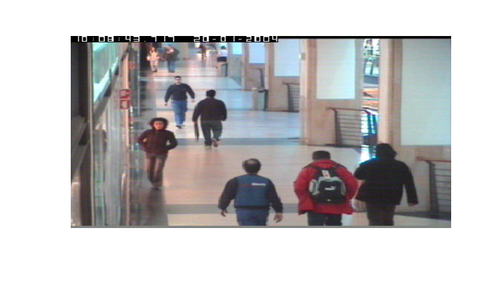

```r
# k, x, y, w, h

library(jpeg)
w <- 384
h <- 288

# f <- 750 #bra frame med en gubbe
# f <- 1200 #bra frame med två gubbar, i varandra
# f <- 1062 # bra för två gubbar, bra perf på den
# f <- 1082 # svår frame, en kille i dörren
# f <- 984
f <- 100 # svår frame, 10 pers
jj <- readJPEG(paste("./caviar_frames2/TwoEnterShop2cor",strrep("0", 4-log10(f-1 + 1)),f-1,".jpg", sep=""), native=FALSE)
background <- readJPEG("./bg.jpg", native=FALSE)
plot(0:1,0:1,type="n",ann=FALSE,axes=FALSE)
rasterImage(jj,0,0,1,1)
```

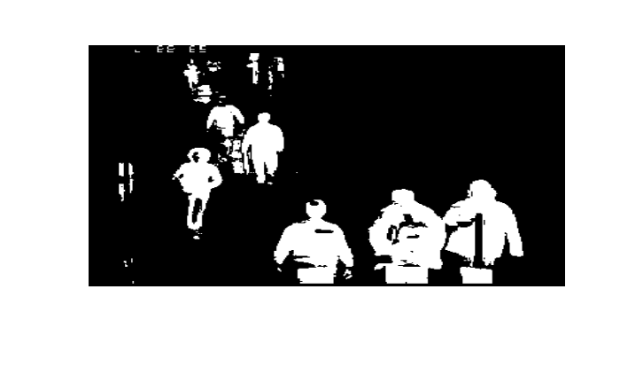

```r
threshold <- 0.2
background_subtraction <- function(img, background) {
  for (i in 1:h) {
    for (j in 1:w) {
      img[i, j, c(1,2,3)] <- max(min(
        ifelse(abs(mean(jj[i, j, c(1,2,3)])-mean(background[i, j, c(1,2,3)])) < threshold, 0, 1)
      , 1), 0)
    }
  }
  return (img)
}

foreground <- background_subtraction(jj, background)

# jj[h, w, 3]
plot(0:1,0:1,type="n",ann=FALSE,axes=FALSE)
rasterImage(foreground,0,0,1,1)
```

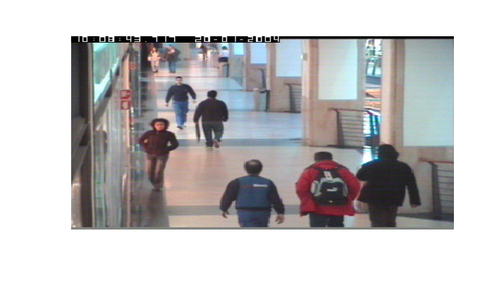

```r
plot(0:1,0:1,type="n",ann=FALSE,axes=FALSE)
rasterImage(jj,0,0,1,1)
```

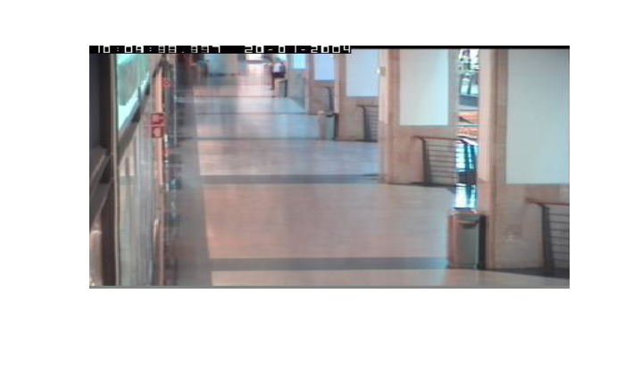

```r
plot(0:1,0:1,type="n",ann=FALSE,axes=FALSE)
rasterImage(background,0,0,1,1)
```

```r
# set.seed(2020)

# ww <- 70
# hh <- 130
# ww <- 17
# hh <- 40
# state = list(
#   k = 10,
#   points = list(
#     list(x = runif(1, 0, w), y = runif(1, 0, h), w = ww, h = hh),
#     list(x = runif(1, 0, w), y = runif(1, 0, h), w = ww, h = hh),
#     list(x = runif(1, 0, w), y = runif(1, 0, h), w = ww, h = hh),
#     list(x = runif(1, 0, w), y = runif(1, 0, h), w = ww, h = hh),
#     list(x = runif(1, 0, w), y = runif(1, 0, h), w = ww, h = hh),
#     list(x = runif(1, 0, w), y = runif(1, 0, h), w = ww, h = hh),
#     list(x = runif(1, 0, w), y = runif(1, 0, h), w = ww, h = hh),
#     list(x = runif(1, 0, w), y = runif(1, 0, h), w = ww, h = hh),
#     list(x = runif(1, 0, w), y = runif(1, 0, h), w = ww, h = hh),
#     list(x = runif(1, 0, w), y = runif(1, 0, h), w = ww, h = hh)
#   )
# )
# xx<-w*.5
# yy <-h*.8
# xx<-w*.3
# yy <-h*.2
xx<-w*.3
yy <-h*.2
ww <- 17
hh <- 40
state = list(
  k = 2,
  points = list(
    list(x = w*.3, y = h*.35, w = 22, h = 60),
    list(x = w*.25, y = h*.15, w = 15, h = 40)#,
    # list(x = xx, y = yy, w = ww, h = hh),
    # list(x = xx, y = yy, w = ww, h = hh),
    # list(x = xx, y = yy, w = ww, h = hh),
    # list(x = xx, y = yy, w = ww, h = hh),
    # list(x = xx, y = yy, w = ww, h = hh),
    # list(x = xx, y = yy, w = ww, h = hh),
    # list(x = xx, y = yy, w = ww, h = hh),
    # list(x = xx, y = yy, w = ww, h = hh)
  )
)
#
# state = list(
#   k = 10,
#   points = list(
#     list(x = w/2, y = h*.8, w = 60, h = 100),
#     list(x = w*.7, y = h*.8, w = 60, h = 100),
#     list(x = w*.85, y = h*.8, w = 60, h = 100),
#     list(x = runif(1, 0, w), y = runif(1, 0, h), w = ww, h = hh),
#     list(x = runif(1, 0, w), y = runif(1, 0, h), w = ww, h = hh),
#     list(x = runif(1, 0, w), y = runif(1, 0, h), w = ww, h = hh),
#     list(x = runif(1, 0, w), y = runif(1, 0, h), w = ww, h = hh),
#     list(x = runif(1, 0, w), y = runif(1, 0, h), w = ww, h = hh),
#     list(x = runif(1, 0, w), y = runif(1, 0, h), w = ww, h = hh),
#     list(x = runif(1, 0, w), y = runif(1, 0, h), w = ww, h = hh)
#   )
# )

plot(0:1,0:1,type="n",ann=FALSE,axes=FALSE)
rasterImage(foreground,0,0,1,1)
```

```r
for (i in 1:state$k) {
  point <- state$points[[i]]
  rect((point$x - point$w/2) / w, 1-(point$y - point$h/2) / h, (point$x + point$w/2)/w, 1-(point$y + point$h/2)/h, col = "red")
}
```

[figure not shown]

```r
state_mask <- array(0, dim=c(h, w, 3))

for (i in 1:state$k) {
  point <- state$points[[i]]
  for (x in round(point$x - point$w/2):round(point$x + point$w/2)) {
    for (y in round(point$y - point$h/2):round(point$y + point$h/2)) {
      if (y >= 1 && y <= h && x >= 0 && x <= w) {
        state_mask[y, x, c(1,2,3)] = 1
      }
    }
  }
}


plot(0:1,0:1,type="n",ann=FALSE,axes=FALSE)
rasterImage(state_mask,0,0,1,1)
```

```r
# cover <- sum(state_mask == 1 & foreground == 1) / sum(foreground)
# cover <- sum(state_mask == foreground) / prod(dim(foreground))
cover <- 0.0001*sum(state_mask == 1 & foreground == 0) + 0.0001*sum(state_mask == 0 & foreground == 1)
exp(-cover)
```

```
[1] 0.6330537
```

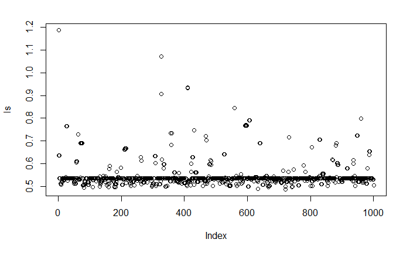

```r
metropolis_hastings <- function(q_sample, q_ratio, pi_ratio, N, initial_state) {
  state <- initial_state

  states <- list(state)

  for (i in 1:N) {
    proposed <- q_sample(state)

    alpha <- q_ratio(state, proposed) * pi_ratio(proposed, state)
    if (alpha >= 1 || runif(1) <= alpha) {
      state <- proposed
    }

    states <- append(states, list(state))
  }

  return (states)
}

propose <- function(state) {
  i <- sample(1:state$k, 1)

  # dx <- (runif(1)-.5)*w *.05
  # dy <- (runif(1)-.5)*h *.05
  #
  # state$points[[i]]$x <- state$points[[i]]$x + dx
  # state$points[[i]]$y <- state$points[[i]]$y + dy

  state$points[[i]]$x <- (runif(1))*w
  state$points[[i]]$y <- (runif(1))*h

  return (state)
}

proposal_prob_ratio <- function(x, y) {
  return (1)
}

likelihood <- function(state) {
  state_mask <- array(0, dim=c(h, w, 3))

  outside <- 0
  for (i in 1:state$k) {
    point <- state$points[[i]]
    # outside <- 0
    for (x in round(point$x - point$w/2):round(point$x + point$w/2)) {
      for (y in round(point$y - point$h/2):round(point$y + point$h/2)) {
        if (y >= 1 && y <= h && x >= 0 && x <= w) {
          state_mask[y, x, c(1,2,3)] = 1
        } else {
          outside <- outside + 1
        }
      }
    }
    # outsides <- outsides + outside
  }

  # print(c(sum(state_mask == 1 & foreground == 0), sum(state_mask == 0 & foreground == 1), sum(state_mask == 1), outside))
  # cover <- 0.0001*sum(state_mask == 1 & foreground == 0) + 0.0001*sum(state_mask == 0 & foreground == 1)+0.0001*outside
  cover <- 0.0001*sum(state_mask == 1 & foreground == 0) + 0.0001*sum(state_mask == 0 & foreground == 1) - 0.0001*sum(state_mask == 1)+0.0001*outside
  return (exp(-cover))
}

pi_ratio <- function(state_1, state_2) {
  likelihood(state_1) /  likelihood(state_2)
}

states <- metropolis_hastings(
  propose,
  proposal_prob_ratio,
  pi_ratio,
  1000,
  state
)

# for (s in states) {
#   plot(0:1,0:1,type="n",ann=FALSE,axes=FALSE)
#   rasterImage(foreground,0,0,1,1)
#
#   for (i in 1:s$k) {
#     point <- s$points[[i]]
#     rect((point$x - point$w/2) / w, 1-(point$y - point$h/2) / h, (point$x + point$w/2)/w, 1-(point$y + point$h/2)/h, col = "red")
#   }
# }

ls <- c()
for (s in states) {
  ls <- c(ls, likelihood(s))
}
plot(ls)
```

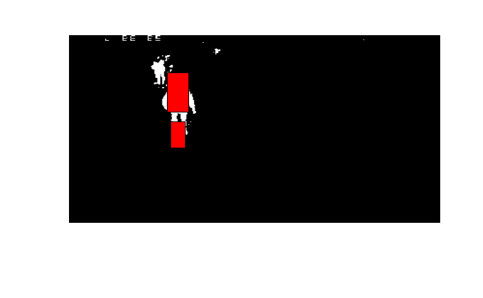

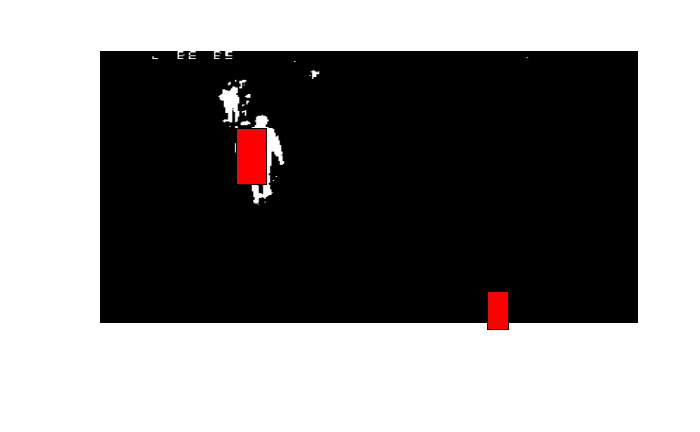

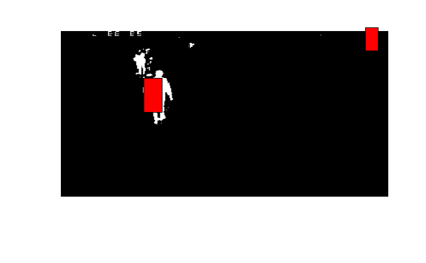

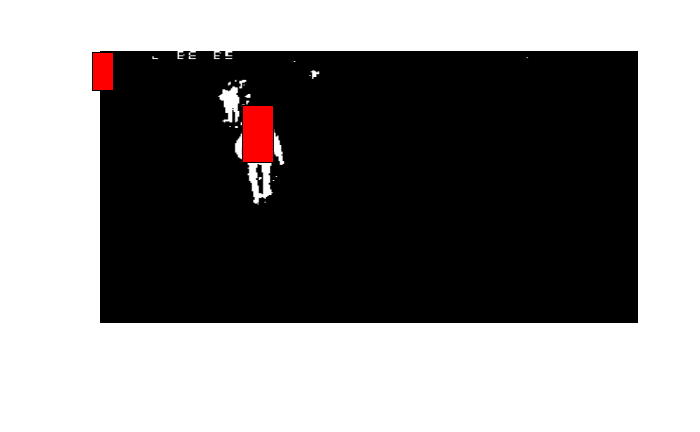

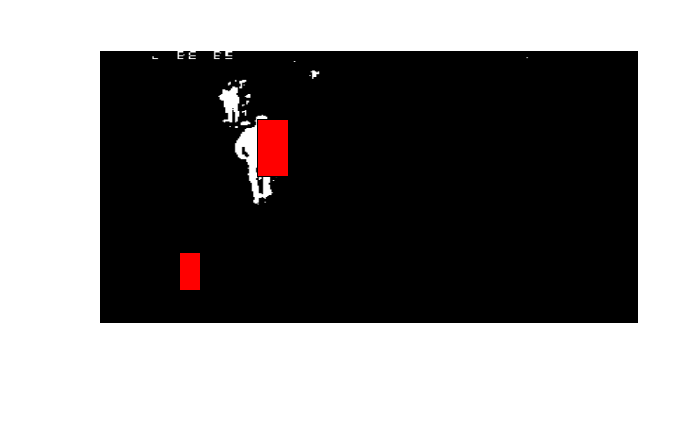

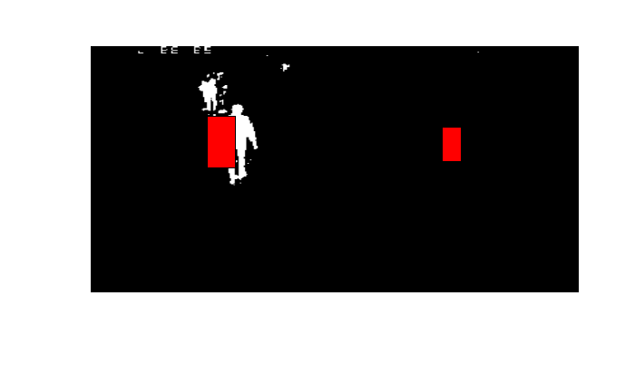

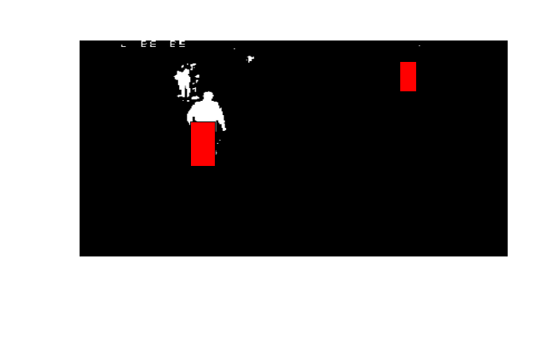

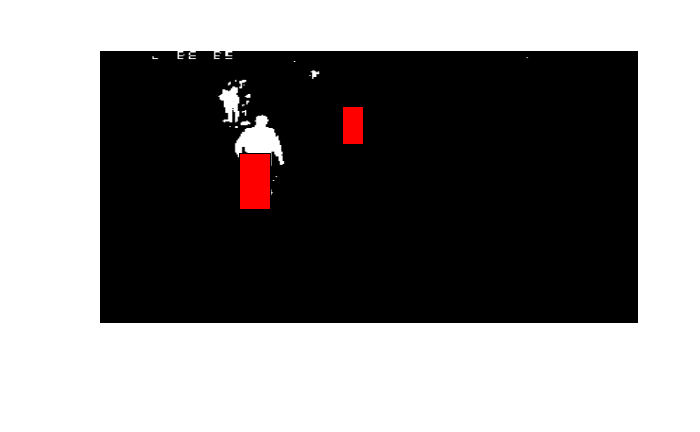

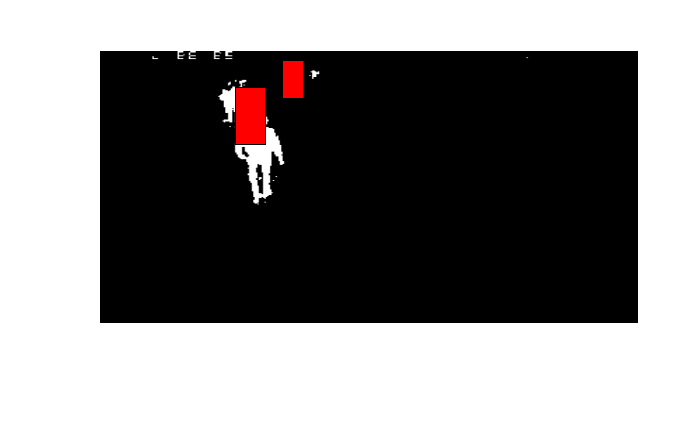

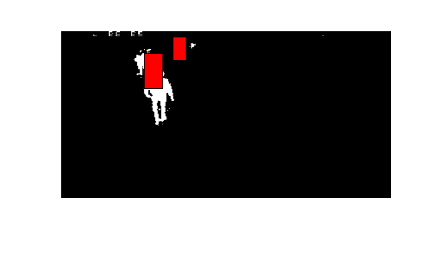

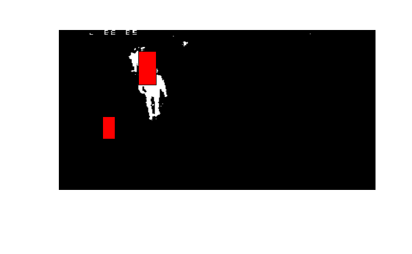

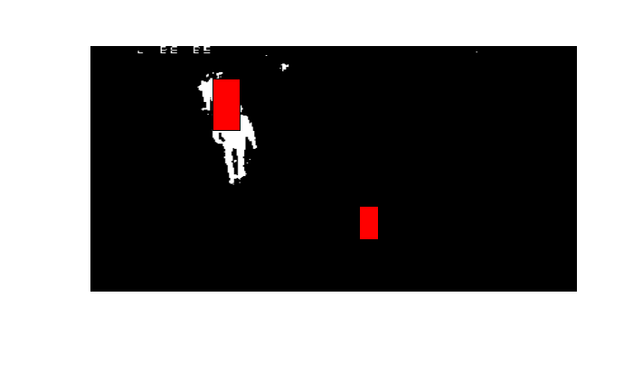

[17 more figures not shown]

```r
# for (s in states[]) {
for (s in states[order(ls, decreasing = 1)[c(seq(1,15),length(states)-seq(1,15)-1)]]) {
  plot(0:1,0:1,type="n",ann=FALSE,axes=FALSE)
  rasterImage(foreground,0,0,1,1)

  for (i in 1:s$k) {
    point <- s$points[[i]]
    rect((point$x - point$w/2) / w, 1-(point$y - point$h/2) / h, (point$x + point$w/2)/w, 1-(point$y + point$h/2)/h, col = "red")
  }
}
```

```r
ls <- c()
for (s in states) {
  ls <- c(ls, likelihood(s))
}
plot(ls)

# for (s in states[]) {
for (s in states[order(ls, decreasing = 1)[c(seq(1,15),length(states)-seq(1,15)-1)]]) {
  plot(0:1,0:1,type="n",ann=FALSE,axes=FALSE)
  rasterImage(foreground,0,0,1,1)

  for (i in 1:s$k) {
    point <- s$points[[i]]
    rect((point$x - point$w/2) / w, 1-(point$y - point$h/2) / h, (point$x + point$w/2)/w, 1-(point$y + point$h/2)/h, col = "red")
  }
}
```

```r
library(mvtnorm)

plot(0:1,0:1,type="n",ann=FALSE,axes=FALSE)
rasterImage(foreground,0,0,1,1)

mean <- c(w*.3, h*.35)
sigmas <- c(w*2, h*2)
sigma <- diag(sigmas)

norm_points <- rmvnorm(100, mean, sigma)

points(norm_points[,1]/w, 1-norm_points[,2]/h, col="red")
```

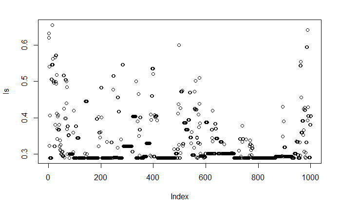

```r
propose <- function(state) {
  i <- sample(1:state$k, 1)

  # dx <- (runif(1)-.5)*w *.05
  # dy <- (runif(1)-.5)*h *.05
  #
  # state$points[[i]]$x <- state$points[[i]]$x + dx
  # state$points[[i]]$y <- state$points[[i]]$y + dy
  norm <- rmvnorm(1, mean, sigma)

  state$points[[i]]$x <- norm[1]
  state$points[[i]]$y <- norm[2]

  return (state)
}

proposal_prob <- function(x) {
  prob <- 1
  for (p in x$points) {
    prob <- prob * dmvnorm(c(p$x, p$y), mean, sigma)
  }
  prob
}

proposal_prob_ratio <- function(x, y) {
  proposal_prob(x)/proposal_prob(y)
}

states <- metropolis_hastings(
  propose,
  proposal_prob_ratio,
  pi_ratio,
  1000,
  state
)

# for (s in states) {
#   plot(0:1,0:1,type="n",ann=FALSE,axes=FALSE)
#   rasterImage(foreground,0,0,1,1)
#
#   for (i in 1:s$k) {
#     point <- s$points[[i]]
#     rect((point$x - point$w/2) / w, 1-(point$y - point$h/2) / h, (point$x + point$w/2)/w, 1-(point$y + point$h/2)/h, col = "red")
#   }
# }

ls <- c()
for (s in states) {
  ls <- c(ls, likelihood(s))
}
plot(ls)
```

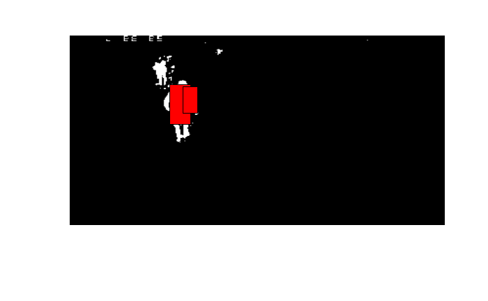

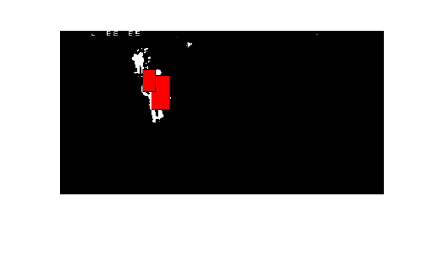

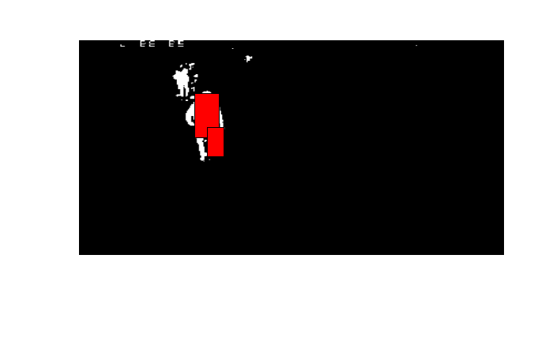

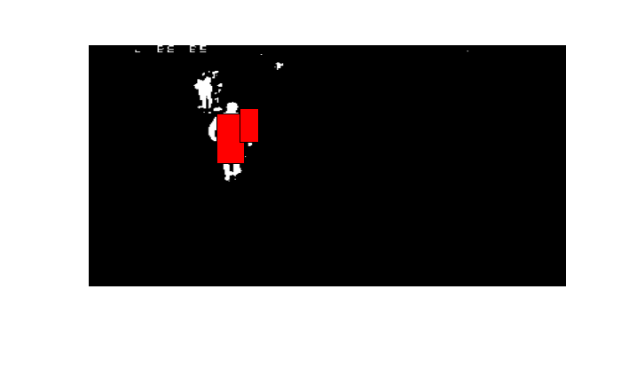

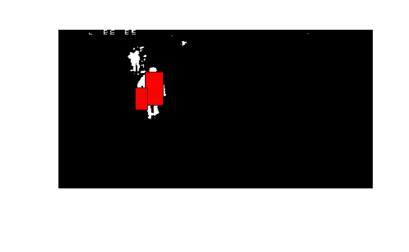

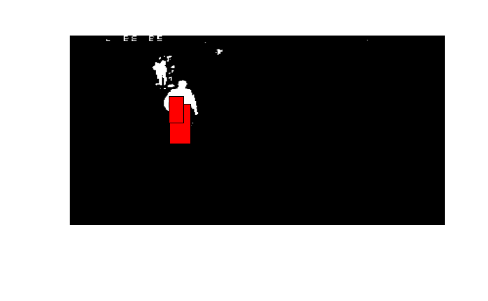

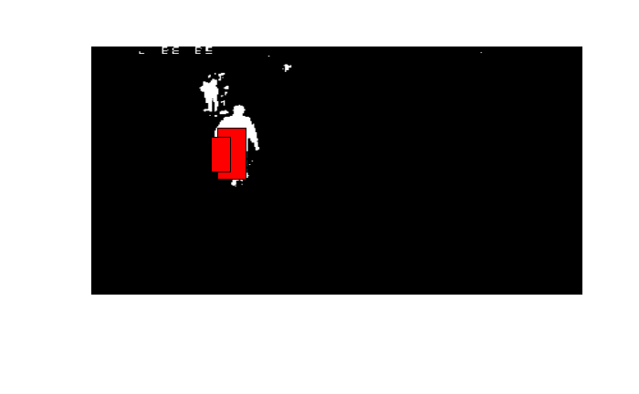

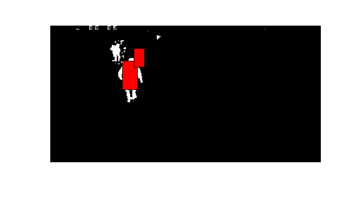

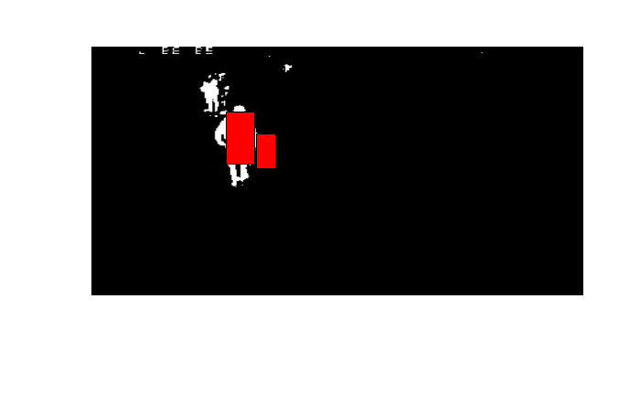

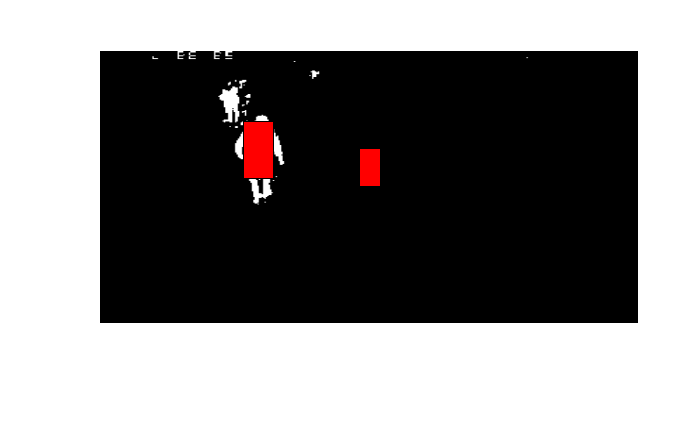

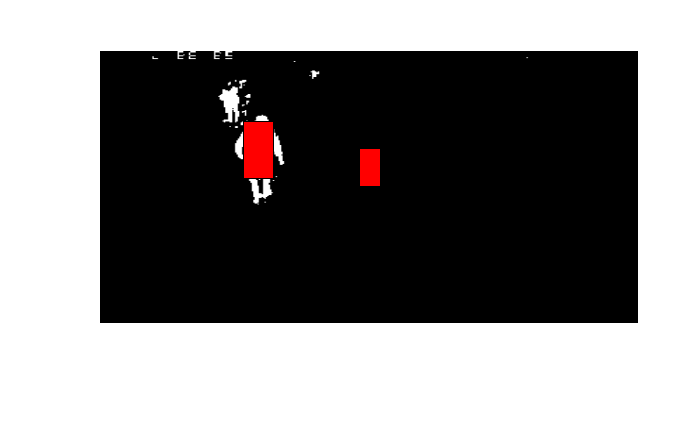

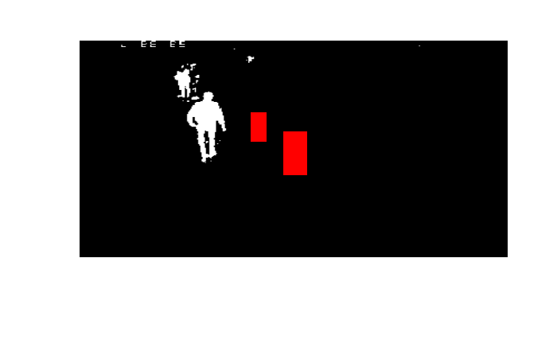

[1 more figures not shown]

```r
# for (s in states[]) {
for (s in states[order(ls, decreasing = 1)[c(seq(1,15),length(states)-seq(1,15)-1)]]) {
  plot(0:1,0:1,type="n",ann=FALSE,axes=FALSE)
  rasterImage(foreground,0,0,1,1)

  for (i in 1:s$k) {
    point <- s$points[[i]]
    rect((point$x - point$w/2) / w, 1-(point$y - point$h/2) / h, (point$x + point$w/2)/w, 1-(point$y + point$h/2)/h, col = "red")
  }
}
```

```r
points <- data.frame()

for (x in 1:w) {
  for (y in 1:h) {
    if (foreground[y, x, 1] == 1) {
      points <- rbind(points, list(x=x,y=y))
    }
  }
}

plot(points$x, h-points$y)

# mean <- c(w*.3, h*.35)
# sigmas <- c(w*2, h*2)
mean <- c(mean(points$x), mean(points$y))
sigmas <- c(sd(points$x)^2, sd(points$y)^2)
sigma <- diag(sigmas)

norm_points <- rmvnorm(100, mean, sigma)

points(norm_points[,1], h-norm_points[,2], col="red")
```

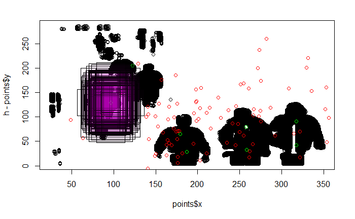

```r
k<-8
clusters <- kmeans(points, k)

points(clusters$centers[,1], h-clusters$centers[,2], col="green")


mean_size <- c(sqrt(mean(clusters$size)), sqrt(mean(clusters$size))*2)
sigma_size <- diag(c(15^2, 30^2))
# sigma_size <- matrix(c(3^2, (3*5)^2,(3*5)^2,5^2), nrow=2,ncol=2)


norm_sizes <- rmvnorm(100, mean_size, sigma_size)
# rect(rep(clusters$centers[1,1], 100), rep(clusters$centers[1,2], 100), norm_sizes[,1], norm_sizes[,1], col = rgb(1,0,0,0.1))

for (i in 1:nrow(norm_sizes)) {
  rect(
    clusters$centers[1,1]-norm_sizes[i,1]/2,
    h-(clusters$centers[1,2]-norm_sizes[i,2]/2),
    clusters$centers[1,1]+norm_sizes[i,1]/2,
    h-(clusters$centers[1,2]+norm_sizes[i,2]/2),
    col = rgb(1,0,1,0.01)
  )
}
```

```r
library(mvtnorm)
# mean_size <- c(20, 50)
# mean_size <- c(sqrt(clusters$size[1]), sqrt(clusters$size[1])*1.5)
# sigma_size <- diag(c(3^2, 5^2))

clamp <- function(x, minv, maxv) {
  return (min(max(x, minv), maxv))
}

# state = list(
#   k = 2,
#   # points = list(
#   #   list(x = runif(1, 0, w), y = runif(1, 0, h), w = ww, h = hh),
#   #   list(x = runif(1, 0, w), y = runif(1, 0, h), w = ww, h = hh)
#   # )
#   points = list(
#     list(x = clusters$centers[1,1], y = clusters$centers[1,2], w = mean_size[1], h = mean_size[2]),
#     list(x = clusters$centers[2,1], y = clusters$centers[2,2], w = mean_size[1], h = mean_size[2])
#   )
# )
state = list(
  k = 8,
  points = list(
    list(x = clusters$centers[1,1], y = clusters$centers[1,2], w = mean_size[1], h = mean_size[2]),
    list(x = clusters$centers[2,1], y = clusters$centers[2,2], w = mean_size[1], h = mean_size[2]),
    list(x = clusters$centers[3,1], y = clusters$centers[3,2], w = mean_size[1], h = mean_size[2]),
    list(x = clusters$centers[4,1], y = clusters$centers[4,2], w = mean_size[1], h = mean_size[2]),
    list(x = clusters$centers[5,1], y = clusters$centers[5,2], w = mean_size[1], h = mean_size[2]),
    list(x = clusters$centers[6,1], y = clusters$centers[6,2], w = mean_size[1], h = mean_size[2]),
    list(x = clusters$centers[7,1], y = clusters$centers[7,2], w = mean_size[1], h = mean_size[2]),
    list(x = clusters$centers[8,1], y = clusters$centers[8,2], w = mean_size[1], h = mean_size[2])#,
    # list(x = clusters$centers[9,1], y = clusters$centers[9,2], w = mean_size[1], h = mean_size[2]),
    # list(x = clusters$centers[10,1], y = clusters$centers[10,2], w = mean_size[1], h = mean_size[2])
  )
)

likelihood <- function(state) {
  state_mask <- array(0, dim=c(h, w, 3))

  outside <- 0
  overlap <- 0
  for (i in 1:state$k) {
    point <- state$points[[i]]
    # outside <- 0
    for (x in round(point$x - point$w/2):round(point$x + point$w/2)) {
      for (y in round(point$y - point$h/2):round(point$y + point$h/2)) {
        if (y >= 1 && y <= h && x >= 1 && x <= w) {
          if (state_mask[y, x, 1] == 1) {
            state_mask[y, x, c(1,2,3)] = 1
          } else {
            overlap <- overlap + 1
          }
        } else {
          outside <- outside + 1
        }
      }
    }
  }

  # cover <- 0.0001*sum(state_mask == 1 & foreground == 0) + 0.0001*sum(state_mask == 0 & foreground == 1)+0.0001*outside
  #
  cover <- 0.0001*sum(state_mask == 1 & foreground == 0) + 0.0001*sum(state_mask == 0 & foreground == 1)+0.0001*outside+0.0001*overlap
  # # print(c(exp(-cover), prior(state)))
  # # print(data.frame(p10=sum(state_mask == 1 & foreground == 0), p01=sum(state_mask == 0 & foreground == 1), outside=outside, eZ=exp(-cover), prior=prior(state)))
  return (exp(-cover) * prior(state))
}

pi_ratio <- function(state_1, state_2) {
  likelihood(state_1) /  likelihood(state_2)
}

propose <- function(state) {
  i <- sample(1:state$k, 1)

  if (runif(1) < 0.9) {
    # norm <- rmvnorm(1, mean, sigma)
    #
    # state$points[[i]]$x <- norm[1]
    # state$points[[i]]$y <- norm[2]
    norm <- rmvnorm(1, c(state$points[[i]]$x, state$points[[i]]$y), diag(c((w*.01)^2, (h*.01)^2)))

    state$points[[i]]$x <- clamp(norm[1], 0, w)
    state$points[[i]]$y <- clamp(norm[2], 0, h)
  } else {
    norm <- rmvnorm(1, mean_size, sigma_size)

    state$points[[i]]$w <- norm[1]
    state$points[[i]]$h <- norm[2]
  }


  return (state)
}

prior <- function(x) {
  prob <- 1
  for (p in x$points) {
    # prob <- prob * dmvnorm(c(p$x, p$y), mean, sigma) * dmvnorm(c(p$w, p$h), mean_size, sigma_size)
    prob <- prob * dmvnorm(c(p$w, p$h), mean_size, sigma_size)
    # print(dmvnorm(c(p$x, p$y), mean, sigma) * dmvnorm(c(p$w, p$h), mean_size, sigma_size))
  }
  prob
}

proposal_prob <- function(x) {
  prob <- 1
  # for (p in x$points) {
  #   prob <- prob * dmvnorm(c(p$x, p$y), mean, sigma) * dmvnorm(c(p$w, p$h), mean_size, sigma_size)
  # }
  for (p in x$points) {
    prob <- prob * dmvnorm(c(p$w, p$h), mean_size, sigma_size)
  }
  prob
}

proposal_prob_ratio <- function(x, y) {
  proposal_prob(x)/proposal_prob(y)
}

states <- metropolis_hastings(
  propose,
  proposal_prob_ratio,
  pi_ratio,
  20000,
  state
)
```